# Synergy screen example

Leiv Rønneberg

05/09/2022

The `synergyscreen` provides a work flow for data from big drug combination screens, where multiple drugs are tested in combination on multiple cell lines. It takes as input a list of experiments, each entry being a list containing the necessary elements needed for a call to the main regression function `bayesynergy`.

# Melanoma cell line example

Included in the package is the result of a `synergyscreen` run of 583 drug combinations on the A-375 human melanoma cell line from ONeil et al. (2016). The `synergyscreen` object is a list with two entries, a dataframe with parameter estimates from each experiment, and a list entitled `failed` – containing experiments that either failed completely to process, or had an unsatisfactory fit.

```r
library(bayesynergy)
data("ONeil_A375")
length(ONeil_A375$failed)
```

```
## [1] 2
```

We see that the dataset has two experiments that failed to process, during an initial run of `synergyscreen`. There’s a multitude of reasons why an experiment might fail to process, it could be an input error, initialization problems or problems with the parallel processing.

The entries of `failed` are themselves lists, each containing the necessary information to process through the `bayesynergy` function

```r
failed_experiment = ONeil_A375$failed[[1]]
names(failed_experiment)
```

```
## [1] "y"             "x"             "drug_names"    "experiment_ID"
```

```r
head(cbind(failed_experiment$y,failed_experiment$x))
```

```
##      viability L778123 MK-4827
## [1,]     0.759   0.325   0.223
## [2,]     0.755   0.325   0.775
## [3,]     0.548   0.325   2.750
## [4,]     0.307   0.325  10.000
## [5,]     0.787   0.800   0.223
## [6,]     0.820   0.800   0.775
```

We can rerun experiments that failed to process, by simply passing the returned `synergyscreen` object back into the function. Note that we turn of the default options of saving each fit and plotting everything, and set `method = "vb"` indicating we use variational inference to fit the model.

```r
fit_screen = synergyscreen(ONeil_A375, save_raw = F, save_plots = F, parallel = F,
                           bayesynergy_params = list(method = "vb"))
```

# Visualization

We can also plot the result of the screen:

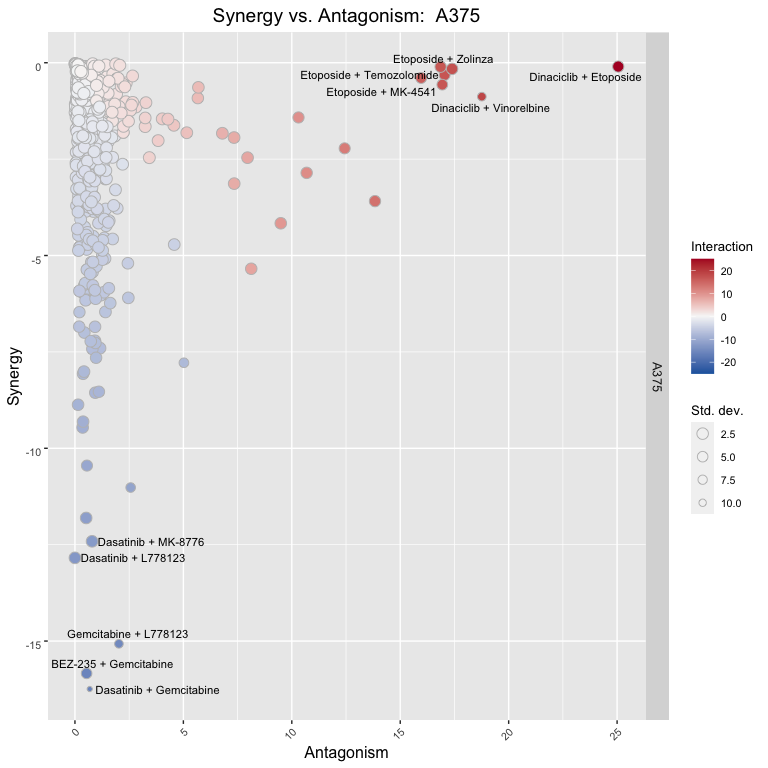

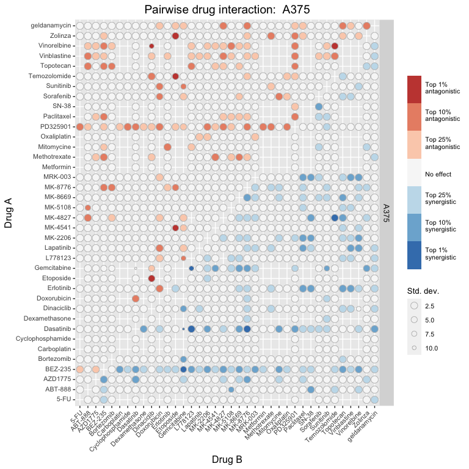

```r
plot(fit_screen)
```

# References

ONeil, Jennifer, Yair Benita, Igor Feldman, Melissa Chenard, Brian Roberts, Yaping Liu, Jing Li, et al. 2016. “An Unbiased Oncology Compound Screen to Identify Novel Combination Strategies.” *Molecular Cancer Therapeutics* 15 (6): 1155–62. https://doi.org/10.1158/1535-7163.mct-15-0843.